# Coverage and uptake of antivirals and neutralising monoclonal antibodies for the treatment of non-hospitalised patients with COVID-19

# Overview

This OpenSAFELY report has been developed to support monitoring the ongoing roll-out of antivirals and neutralising monoclonal antibodies (nMABs) for the treatment of COVID-19, based on the population of 25.1m people registered with practices that use TPP SystmOne software. Since January 2022 this report has been updated several times to include new data. Consequently, there are likely to be small changes between some versions.

Between December 2021 and June 2023 the delivery of antivirals and nMABS was undertaken in COVID-19 Medicine Delivery Units (CMDUs). The COVID-19 therapeutics dataset captured information about COVID-19 treatments during this period, and is utilised in the generation of this reports. The [final publication](https://www.england.nhs.uk/statistics/statistical-work-areas/covid-therapeutics-antivirals-and-neutralising-monoclonal-antibodies/) of that dataset included data up to the end of June 2023. Therefore, the reporting below covers the period December 2021 to June 2023.

Note that currently the clinician-assigned risk group for patients receiving Paxlovid or Remdesivir is not available. While we’re able to assign high risk groups to about 70% of these patients by implementing the NHS Digital logic, the other 30% are most likely identified via non-digital routes. For now, where results are broken down by high risk cohort and no high risk cohort is able to assigned, these patients are excluded.

The code and data for this report can be found in the OpenSAFELY [antibody-and-antiviral-deployment repository](https://github.com/opensafely/antibody-and-antiviral-deployment). The accompanying manuscript is published in BMJ Medicine [doi:10.1136/bmjmed-2022-000276](http://dx.doi.org/10.1136/bmjmed-2022-000276).

*Update: The release date of this report can be found at the top. If you have any questions about this report please contact team@opensafely.org.*

##### Contents

- Introduction
- Results
  - Coverage of COVID-19 treatment
  - High risk patient cohorts
  - Key demographic and clinical characteristics of treated patients
  - Consistency with guidance
  - Time to treatment
  - Variation by STP
- Methods

# Introduction

While vaccines remain the best strategy to prevent COVID-19, evidence suggests neutralising monoclonal antibodies (nMABs) or antivirals could potentially benefit certain vulnerable populations before or after exposure to SARS-CoV-2, such as the unvaccinated or recently vaccinated high-risk patients. On 11th December 2021, COVID-19 Medicine Delivery Units (CMDUs) were launched across England, offering antiviral medicines and neutralising monoclonal antibodies (nMABs) as treatment to patients with COVID-19 at high risk of severe outcomes in outpatient clinics or their own home.

With the roll-out of nMABs and antivirals, there is a need to assess the coverage of these new treatments amongst these patients, such as factors of relevance in determining nMAB and antiviral treatment and the impact of nMAB and antiviral treatment in the community and hospital settings.

Using the OpenSAFELY platform we have developed and delivered a rapid, near real-time data-monitoring framework for the roll-out of antivirals and nMABs in England that can deliver detailed coverage reports in fine-grained clinical and demographic risk groups, using publicly auditable methods, using linked but pseudonymised patient-level NHS data in a highly secure Trusted Research Environment.

Full methods in code form can be found in the accompanying [antibody-and-antiviral-deployment repository](https://github.com/opensafely/antibody-and-antiviral-deployment) and are also described in our paper [doi:10.1136/bmjmed-2022-000276](http://dx.doi.org/10.1136/bmjmed-2022-000276). Brief methods can be found at the end of this report.

# Results

### Overall coverage of COVID-19 treatment

Between **11-Dec-2021** and **30-Jun-2023**, a total of 169,980 non-hospitalised patients registered at a TPP practice in England were identified as potentially being eligible for receiving an antiviral or nMAB for treating COVID-19. Of the 169,980 potentially eligible patients, (17%) were classified into more than one high risk cohort (high risk cohort count range 1 - 7). The number of patients potentially eligible in each high risk cohort is described in Figure 1 and Table 1 below.

Of the 169,980 potentially eligible patients, 47,660 (**28%**) received treatment from a CMDU (Table 1, Figure 2);

- Paxlovid: 18,830;
- Sotrovimab: 17,420;
- Remdesivir: 210;
- Molnupiravir: 11,150;
- Casirivimab: 50.

**Figure 1 Cumulative total of potentially eligible patients for receiving an antiviral or nMABs for treating COVID-19 since 11th December 2021, stratified by high risk cohort.** Patients are considered eligible on the date of their positive SARS-CoV-2 test. Note, patients can appear in more than one high risk group, and the overall number in each group is likely to be an overestimation due to including SARS-CoV-2 infection confirmed by either lateral flow or PCR test (where only PCR-confirmed infections should have been treated according to guidance in effect prior to 10th February 2022), and potentially including non-symptomatic patients.

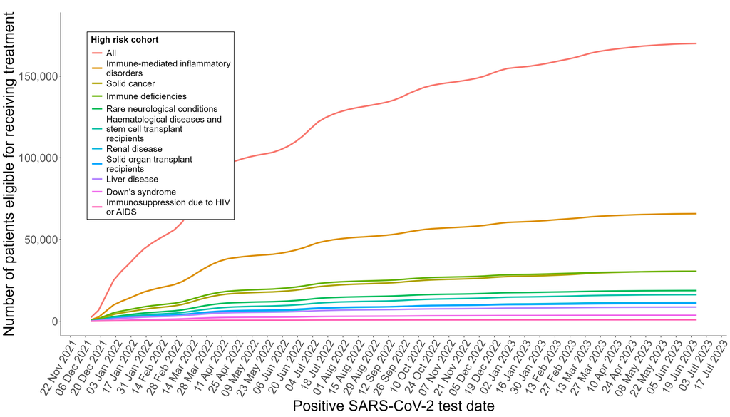

**Figure 2 Cumulative total of patients who received an antiviral or nMAB for treating COVID-19 since 11th December 2021, stratified by (a) treatment type and (b) high risk cohorts.** Shorter lines for Paxlovid and casirivimab reflect availability and guidance. Note, treated patients can appear in more than one high risk group.

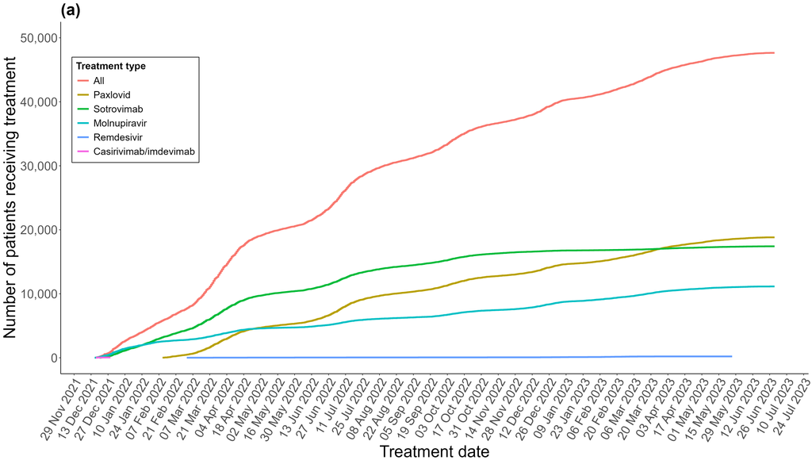

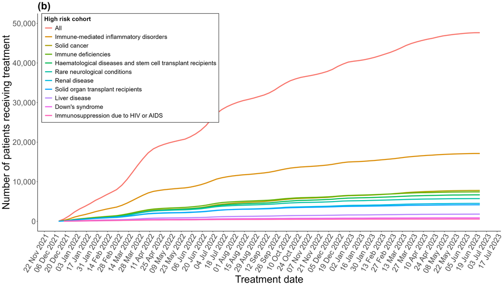

**Table 1 Count and proportion of potentially eligible patients in OpenSAFELY-TPP who have received treatment for COVID-19 since 11th December 2021, broken down by high risk cohort and treatment type.** Patient counts of 0-7 are shown as <8 with remaining counts rounded to the nearest 10; as a result percentages may not add up to 100%

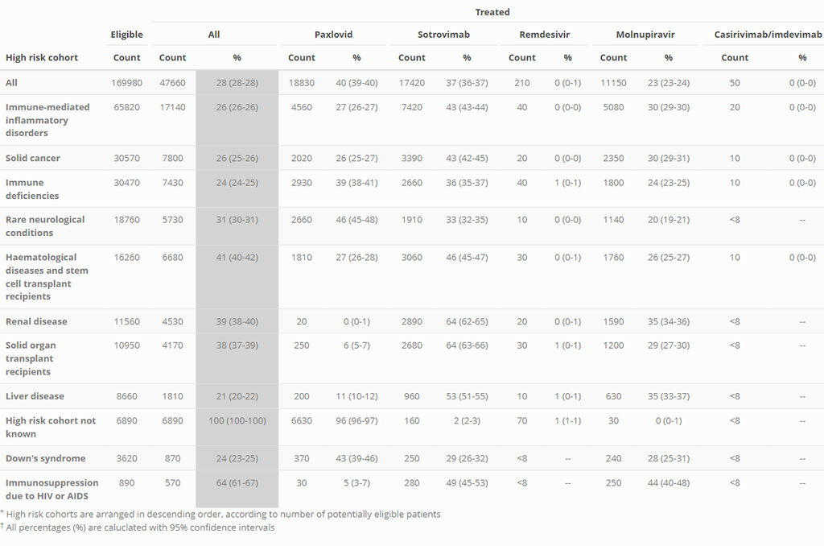

### High risk patient cohorts

The proportion of potentially eligible patients receiving treatment varied over time and by high risk cohort (Figure 3).

**Figure 3 Weekly proportion of eligible patients receiving an antiviral or nMAB for treating COVID-19 since 11th December 2021, stratified by high risk cohort.** Proportions are rounded to 2 decimal places.

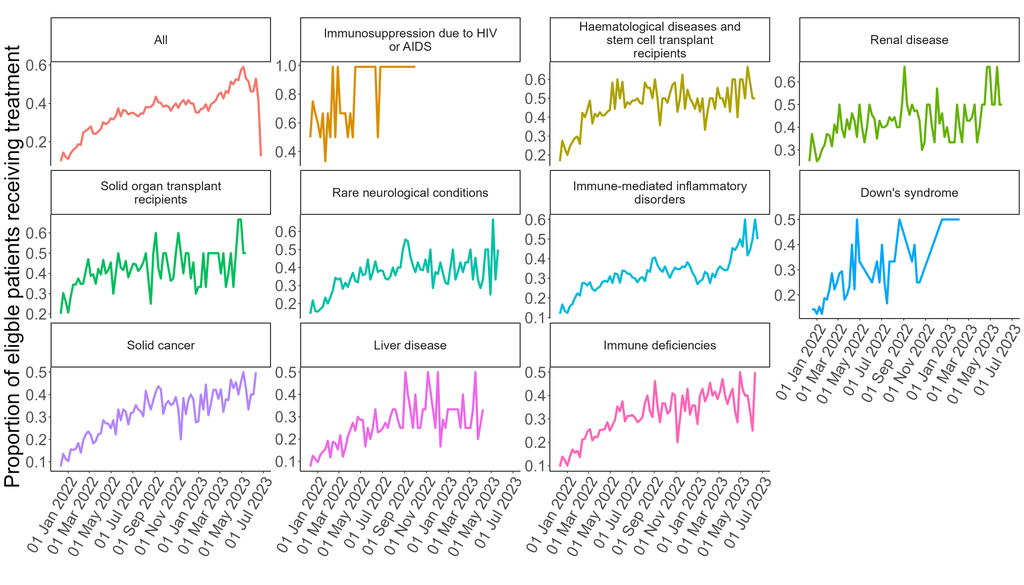

### Key demographic and clinical characteristics of treated patients

Table 2 shows the count and proportion of potentially eligible patients who received treatment for COVID-19 by 30-Jun-2023, broken down by demographic and clinical categories and by treatment type. The proportion treated varied by ethnicity, NHS Regions and by rurality. There was also lower coverage among care home residents, those with dementia, those with sickle cell disease, unvaccinated patients and in the most socioeconomically deprived areas. Patients who were housebound, or who had a severe mental illness also had a slightly reduced chance of being treated.

**Table 2 Count and proportion of potentially eligible patients in OpenSAFELY-TPP who have received treatment for COVID-19 since 11th December 2021, broken down by demographic and clinical categories and by treatment type.** Patient counts of 0-7 are shown as <8 with remaining counts rounded to the nearest 10; as a result percentages may not add up to 100%.

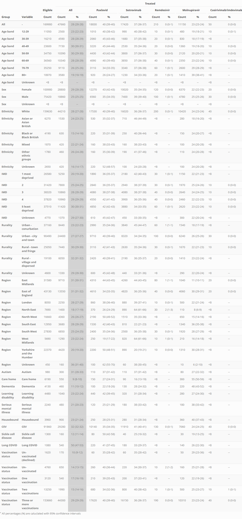

### Consistency with guidance

Of the 47,660 patients who received treatment for COVID-19 between 11-Dec-2021 and 30-Jun-2023, 18,570 (39%) patients were missing records needed to confirm eligibility; 14% did not have evidence of a positive SARS-CoV-2 test, 29% did not have a high risk cohort identified from their GP records alone, and 2% were admitted to the hospital on or before their date of positive test but were not discharged on or before that date. There were also a small number of other potential inconsistencies with guidance for patients who received treatment, such as having a potential contraindication to the treatment given (Figure 4).

**Figure 4 Breakdown of possible inconsistencies with guidance on eligibility/exclusion criteria in treated COVID-19 patients.** Treatment eligibility window for Paxlovid, sotrovimab and molnupiravir was 5 days from positive SARS-CoV-2 test (used as a proxy for symptom onset date) and 7 days for remdesivir.

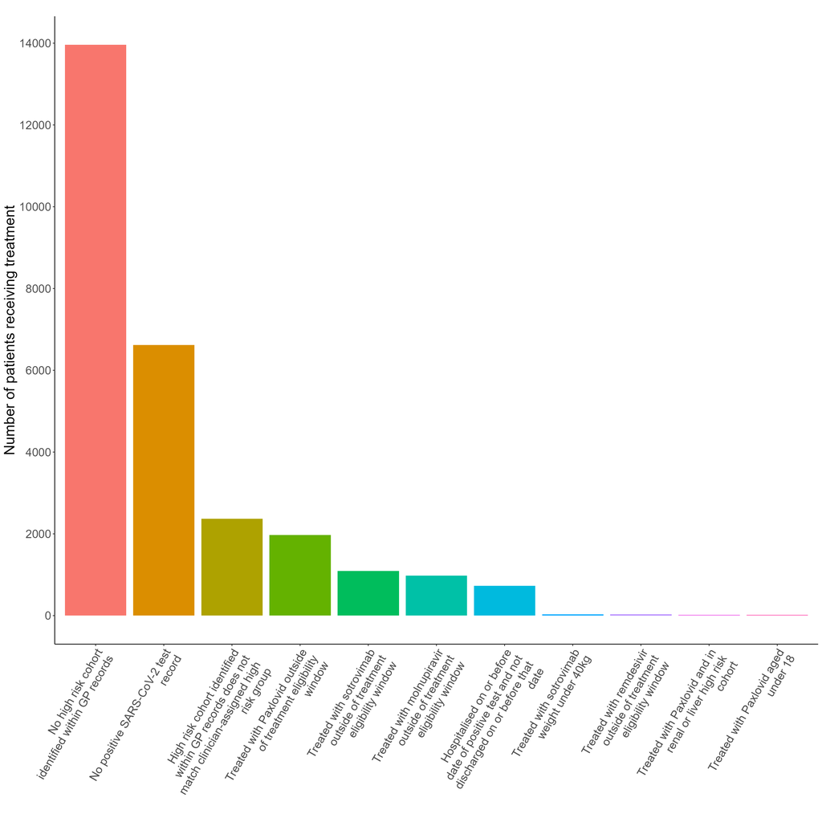

### Time to treatment

Overall, of the 47,660 patients who received treatment, 77% did so within the respective treatment-specific eligibility window as estimated from test date (as symptom date is not consistently available) (Figure 5).

**Figure 5 Time (number of days) between positive SARS-CoV-2 test and treatment for COVID-19, broken down by (a) treatment type and (b) high risk cohort.** Treatment types are restricted to the three most commonly used treatments.

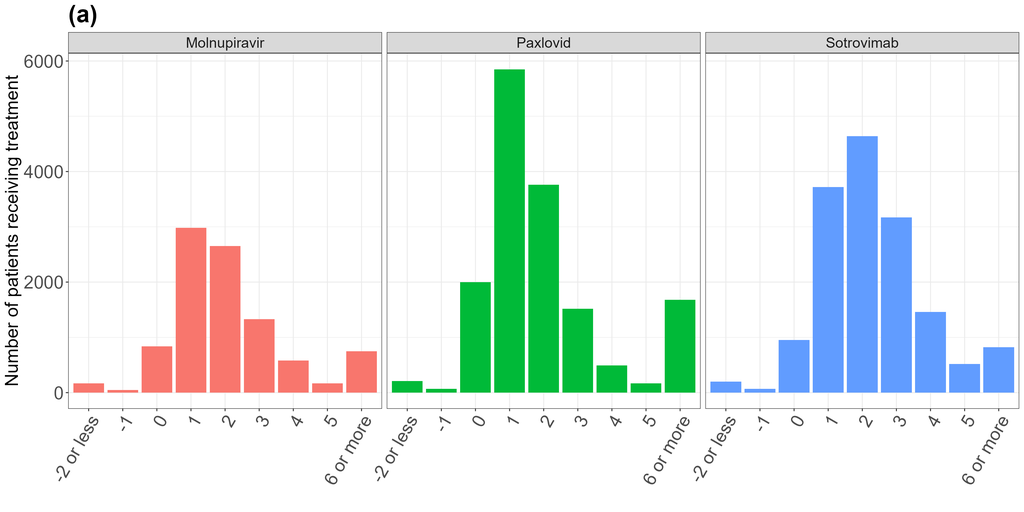

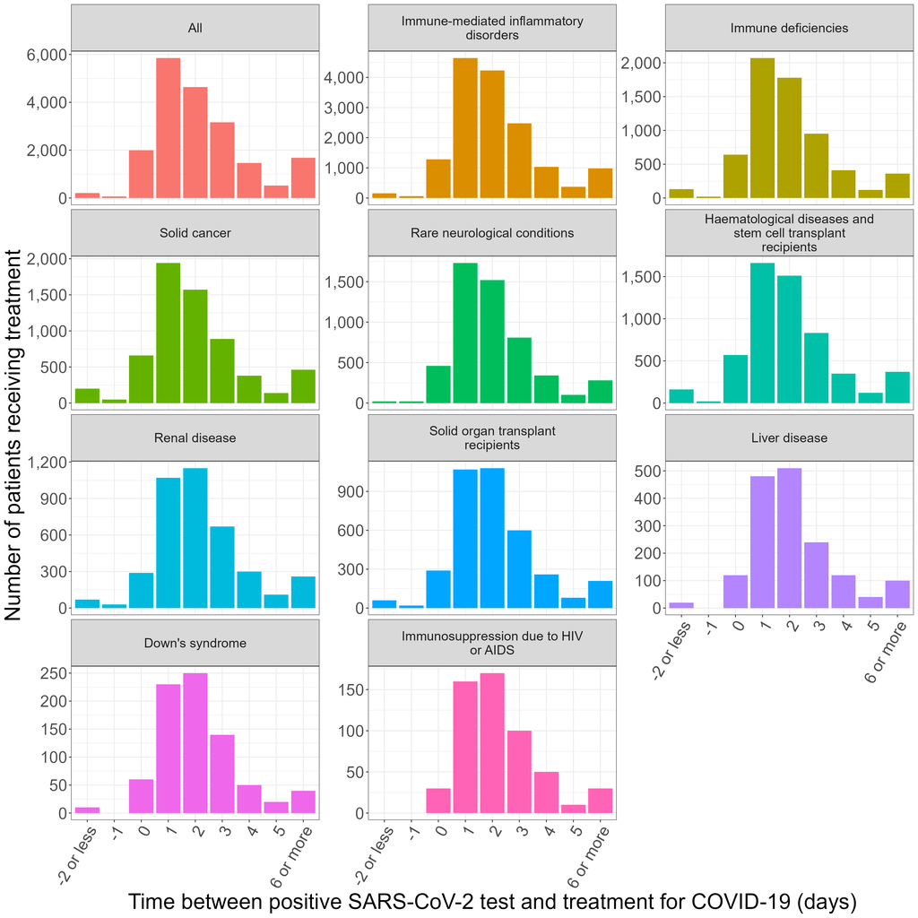

### COVID-19 Medicines Delivery Units

Details of all CMDUs can be found on the [national website](https://digital.nhs.uk/coronavirus/covid-medicine-delivery-unit-directory?key=h58vqkRUup40o27K04xOrtfh7ZXqwRQoOLhXTkGWlbOrVSkwzfTeetw39uGFlc28). As data on CMDU was not available, Sustainability and Transformation Plan (STP), which has almost a 1:1 mapping, was used as a proxy to identify any variation in the proportion of patients treated between CMDUs. Note, the subset of the population covered by TPP in each STP may not be representative of the whole STP and STPs were only included if they had greater than 10% population coverage in TPP practices. Practice-STP mappings, used to calculate the coverage, were calculated as of March 2020 and it is likely that since then some borders and population sizes may have changed.

**Figure 6 Weekly proportion of eligible patients receiving an antiviral or nMAB for treating COVID-19 since 11th December 2021, stratified by STP decile.**

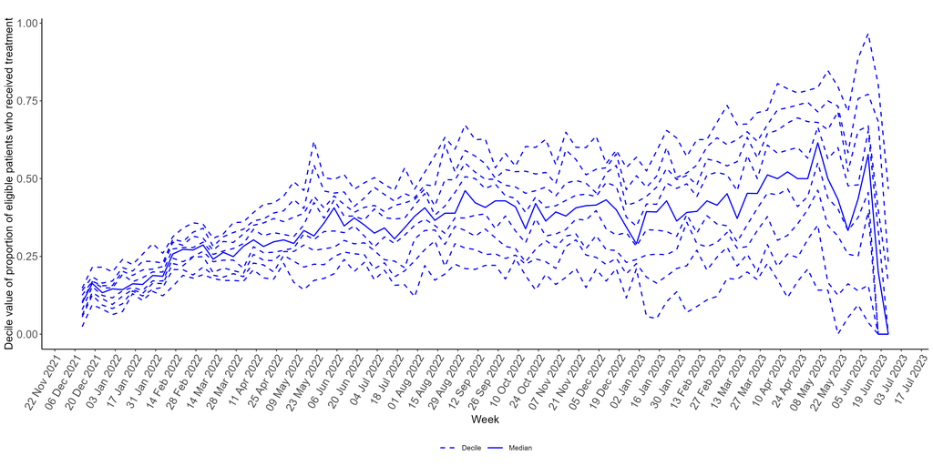

**Figure 7 Total number of patients who received an antiviral or nMAB for treating COVID-19 since 11th December 2021, stratified by treatment type based on the most recent recorded treatment code recorded** Shorter lines for Paxlovid and casirivimab reflect availability and guidance.

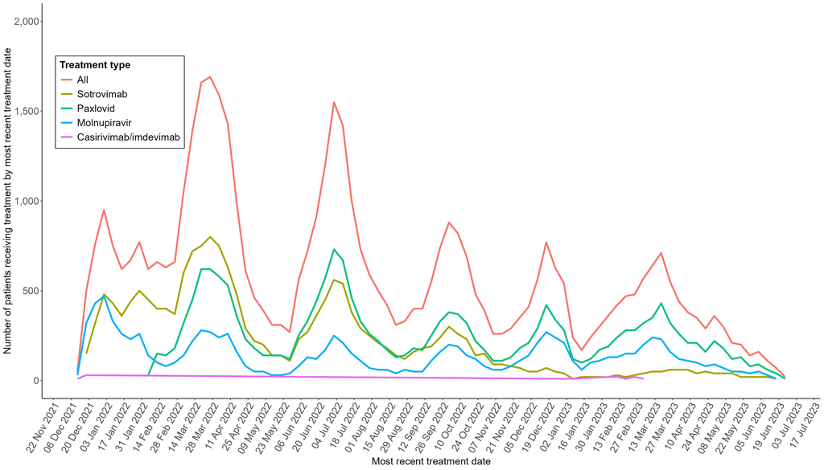

# Methods

Full methods in code form can be found in the accompanying [antibody-and-antiviral-deployment repository](https://github.com/opensafely/antibody-and-antiviral-deployment) and are also described in our paper, linked above. Brief methods are given below.

### Data sources

All data were analysed securely through OpenSAFELY-TPP https://opensafely.org which contains the full pseudonymised primary care records for all patients currently registered with general practices using TPP SystmOne software (approximately 25.1 million, approx.40% of the English population). Data were linked with accident and emergency (A&E) attendance and in-patient records from NHS Digital; national coronavirus testing records from the Second Generation Surveillance System (SGSS); and the “COVID-19 therapeutics dataset”, a patient-level dataset on antiviral and nMAB treatments from NHS England, derived from software used to notify NHS England of COVID-19 treatments.

### Study population

##### Base population

- Patients with either a positive SARS-CoV-2 test on or after 11th December 2021 (this is the earliest date that a patient could have tested positive and still been eligible for receiving treatment when they became available from CMDUs from 11th December 2021) or with a treatment record on or after 11th December 2021, who were also registered at the time of their test/treatment.
- Patients aged under 12 or with an unknown date of birth were excluded.

##### Eligible patients

Where possible eligibility criteria were applied as per the Interim Clinical Commissioning Policy for non-hospitalised COVID-19 patients (NHSE, 28/01/2022) this included:

- SARS-CoV-2 infection confirmed by a PCR or lateral flow test
- being a member of a high risk cohort (determined by applying the detailed codelists and logic from NHS Digital as far as possible)

There were two main differences to the official criteria in our implementation. Firstly, prior to 10th February 2022, infection should have been confirmed by a PCR test, however this was then relaxed to include lateral flow tests. We were not able to always distinguish between lateral flow and PCR tests in all test records, and therefore included all positive SARS-CoV-2 test results. Secondly, having symptomatic COVID-19 was also an eligibility criteria: however due to difficulties in determining symptom status (i.e. it was only possible to determine whether a patient’s positive test had a “symptomatic” flag at the time of the test, but not whether symptoms developed later) we did not implement this requirement in our analysis; however we do address this in a separate sensitivity analysis, where we restricted the potentially eligible population to only those with a “symptomatic” flag associated with their positive SARS-CoV-2 test to determine its use as an indicator of being potentially asymptomatic.We also included patients in the eligible population if they were in the Treated cohort below.

##### Treated patients

- Treatments and the date they were given were identified in the COVID-19 therapeutics dataset, restricted to those treated in the community (“non_hospitalised”)
- Patients issued more than one treatment within two weeks of one another, or with an implausible treatment date (e.g. far in the future) were excluded

### Key demographic and clinical characteristics

We classified treated patients by age group, sex, NHS region of their general practice and other key demographics including ethnicity and the level of deprivation. Deprivation was measured by Index of Multiple Deprivation (IMD), in quintiles, derived from the patient’s postcode at lower super output area level for a high degree of precision. Ethnicity was ascertained using 270 clinical codes grouped into broad categories White, Black or Black British, Asian or Asian British, Mixed, Other, and Unknown. Individuals with missing sex, ethnicity, IMD or region were included as “Unknown”. Treated patients were described according to whether they were in other groups of interest who are sometimes subject to variation in care, including autism, dementia, learning disability, serious mental illness, care home residents, and housebound. In addition we classified treated patients by their COVID-19 vaccination status (unvaccinated, unvaccinated with a record of declining vaccination, one vaccination, two vaccinations, or three or more).

### Consistency with guidance

For patients who received treatment but who were not otherwise identified as potentially being eligible for treatment, we report which eligibility or exclusion criteria were not met according to the data available (i.e. no positive SARS-CoV-2 test result, or not identified as part of a high risk group). Where possible within available data, we also report other potential inconsistencies with guidance for patients who received treatment, such as where the high risk cohort identified within their records did not match the high risk cohort associated with their treatment.

### Descriptive statistics

We generated charts showing the cumulative number of potentially eligible and treated patients per week, stratified by high risk group, and also stratified by treatment type for treated patients. We used simple descriptive statistics to summarise the counts and proportions of potentially eligible patients treated, stratified by treatment type and either high risk cohort or clinical and demographic groups, and to describe potential inconsistencies with guidelines. Charts and results not presented in this manuscript are available online for inspection in the associated Github antibody-and-antiviral-deployment repository. Patient counts of 0-7 are shown as “<8” with remaining counts rounded to the nearest 10 to protect against small number differences in our routinely updating data. All percentages (%) are calculated with 95% confidence intervals (CI).

### Codelists

Detailed information on compilation and sources for every individual codelist are available at https://www.opencodelists.org/.